# Team X - Lab 5

## Model 2 (time-varying intercept + static slope)

2. Fit the full Ricker model with a time-varying intercept and a static effect of spawners. For this model, obtain the time series of $\alpha_t$, which is an estimate of the stock productivity in the absence of density-dependent effects. How do these estimates of productivity compare to those from the previous question? Plot the ts of $\alpha_t$ and note the AICc for this model. Also plot appropriate model diagnostics. ($Hint$: If you don’t want a parameter to vary with time, what does that say about its process variance?)

```r
# Model 2: Full Ricker with time-varying intercept + static density dependence
# This adds the effect of spawner density (negative effect on productivity)
# log(R_t/S_t) = α_t - β*S_t + v_t  (observation equation)
# α_t = α_{t-1} + w_t                (state equation - α varies over time)
# β = constant                       (density effect is static - no process variance)

# key difference is adding spawners as a covariate, meaning the relationship between year and log(R/S) can vary by density
spawners_cov <- matrix(SR_clean$spawners, nrow = 1) # need spawners as a covariate

# should be logged
log_spawners_cov <- matrix(log(SR_clean$spawners), nrow = 1) # need spawners as a covariate

mod.list.2 <- list(
  B = matrix(1),        # alpha_t = alpha_{t-1} + w_t
  U = matrix(0),
  Q = "unconstrained",  # alpha_t has process error
  Z = matrix(1),        # observation = alpha_t + beta*covariate + v_t
  A = matrix(0),
  R = "unconstrained",
  x0 = "unconstrained",
  D  = matrix("beta1", nrow = 1),        # coefficient of covariate beta (use D not C)
  d = log_spawners_cov  # covariate matrix of logged spawner counts (use d not c)
)

# Fit the model
SlopeIntcptVarying <- MARSS(logRS, mod.list.2, control = list(maxit = 5000))
```

```
## Success! abstol and log-log tests passed at 24 iterations.
## Alert: conv.test.slope.tol is 0.5.
## Test with smaller values (<0.1) to ensure convergence.
##
## MARSS fit is
## Estimation method: kem
## Convergence test: conv.test.slope.tol = 0.5, abstol = 0.001
## Estimation converged in 24 iterations.
## Log-likelihood: -51.87178
## AIC: 111.7436   AICc: 112.7962
##
##         Estimate
## R.R      0.21148
## Q.Q      0.30308
## x0.x0    1.01246
## D.beta1 -0.00128
## Initial states (x0) defined at t=0
##
## Standard errors have not been calculated.
## Use MARSSparamCIs to compute CIs and bias estimates.
```

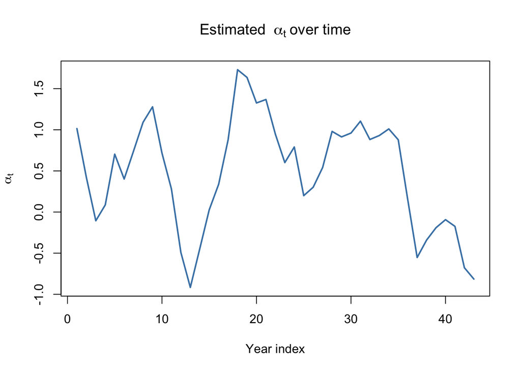

```r
alpha_t <- SlopeIntcptVarying$states[1, ]  #Extract the estimated alpha_t values (states)
plot(alpha_t, type = "l", lwd = 2, col = "steelblue",
     ylab = expression(alpha[t]), xlab = "Year index",
     main = expression("Estimated "~alpha[t]~"over time"))
```

## Model 3 (time-varying intercept + static slope + summer PDO)

3. Fit the expanded model that includes the summer PDO index as the covariate (`pdo_summer_t2`). What is the mean level of productivity? Plot the ts of $\delta_t$ and note the AICc for this model. Also plot appropriate model diagnostics.

```r
# Model 3: Time-varying intercept (baseline productivity) and fixed slope (effect of spawners)
# with summer PDO as a covariate
library(MARSS)
library(ggplot2)
library(dplyr)
library(ggpubr)

years = SR_clean$brood_year
TT    = length(years)
logSR = matrix(SR_clean$log_RS, nrow = 1)
X     = matrix(SR_clean$pdo_summer_t2, nrow = 1)
St    = matrix(SR_clean$spawners, nrow = 1)

# Combine covariates into one 2 x TT matrix
covariates = rbind(X, log(St))

# Model specification
mod.list = list(
  B  = matrix(1),              # random walk for alpha[t]
  U  = matrix(0),              # no drift
  Q  = matrix("q.alpha"),      # variance of alpha[t]
  Z  = matrix(1),              # alpha[t] directly maps to obs
  A  = matrix(0),              # no additional offset
  R  = matrix("r"),            # obs error
  x0 = matrix(0),             # initial state
  D  = matrix(c("beta1", "-beta2"), nrow = 1),  # note: -beta2 for negative effect
  d  = covariates              # 2 x TT matrix
)

mod3 = MARSS(logSR, mod.list)
```

```
## Success! abstol and log-log tests passed at 75 iterations.
## Alert: conv.test.slope.tol is 0.5.
## Test with smaller values (<0.1) to ensure convergence.
##
## MARSS fit is
## Estimation method: kem
## Convergence test: conv.test.slope.tol = 0.5, abstol = 0.001
## Estimation converged in 75 iterations.
## Log-likelihood: -52.34381
## AIC: 112.6876   AICc: 113.7403
##
##           Estimate
## R.r        0.23146
## Q.q.alpha  0.28949
## D.beta1   -0.00408
## D.-beta2   0.05620
## Initial states (x0) defined at t=0
##
## Standard errors have not been calculated.
## Use MARSSparamCIs to compute CIs and bias estimates.
```

```r
mod3CIs = MARSSparamCIs(mod3)

print(mod3CIs)
```

```
##
## MARSS fit is
## Estimation method: kem
## Convergence test: conv.test.slope.tol = 0.5, abstol = 0.001
## Estimation converged in 75 iterations.
## Log-likelihood: -52.34381
## AIC: 112.6876   AICc: 113.7403
##
##             ML.Est Std.Err   low.CI up.CI
## R.r        0.23146  0.1135  0.00896 0.454
## Q.q.alpha  0.28949  0.1462  0.00291 0.576
## D.beta1   -0.00408  0.1453 -0.28894 0.281
## D.-beta2   0.05620  0.0611 -0.06356 0.176
## Initial states (x0) defined at t=0
##
## CIs calculated at alpha = 0.05 via method=hessian
```

```r
cat("AICc:", mod3$AICc, "\n")
```

```
## AICc: 113.7403
```

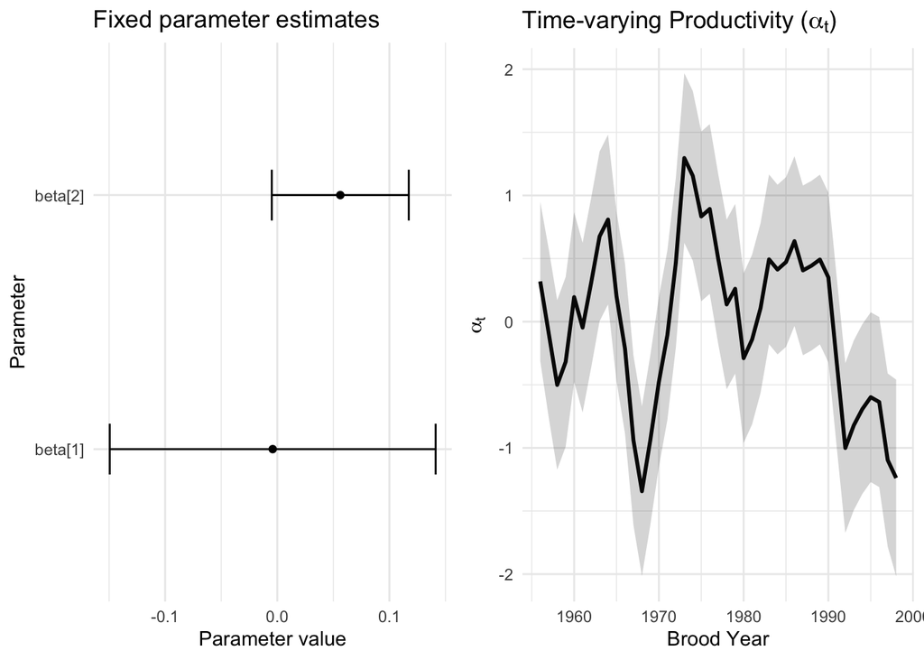

```r
# Extract and plot fixed parameter means and SEs
beta_1_mu = mod3CIs$parMean[1]
beta_1_se = mod3CIs$par.se$A[1,1]
beta_2_mu = mod3CIs$parMean[2]
beta_2_se = mod3CIs$par.se$A[2,1]

# Extract the states
alpha_mu = mod3$states[1, ]
alpha_se = mod3$states.se[1, ]

ggarrange(
data.frame(
  Parameter = c("beta[1]", "beta[2]"),
  Mean = c(beta_1_mu, beta_2_mu),
  SE = c(beta_1_se, beta_2_se)
) %>%

  ggplot(aes(x = Parameter, y = Mean)) +
  geom_point() +
  geom_errorbar(aes(ymin = Mean - SE, ymax = Mean + SE), width = 0.2) +
  ggtitle("Fixed parameter estimates") +
  coord_flip() +
  theme_minimal() +
  ylab("Parameter value")

,

data.frame(
  year  = years,
  alpha = alpha_mu,
  se    = alpha_se
) %>%

  ggplot(aes(x = year, y = alpha)) +
  geom_line(size = 1) +
  geom_ribbon(aes(ymin = alpha - 2 * alpha_se, ymax = alpha + 2 * alpha_se), alpha = 0.2) +
  labs(title = expression(paste("Time-varying Productivity (", alpha[t], ")")),
       x = "Brood Year", y = expression(alpha[t])) +
  theme_minimal()
)
```

## Model 4 (time-varying intercept + static slope + winter PDO)

4. Fit the expanded model that includes the winter PDO index as the covariate (`pdo_winter_t2`). What is the mean level of productivity? Plot the ts of $\delta_t$ and note the AICc for this model. Also plot appropriate model diagnostics.

```r
# Model 4: Time-varying intercept (baseline productivity) and fixed slope (effect of spawners)
# with winter PDO as a covariate
library(MARSS)
library(ggplot2)
library(dplyr)
library(ggpubr)

years = SR_clean$brood_year
TT    = length(years)
logSR = matrix(SR_clean$log_RS, nrow = 1)
X     = matrix(SR_clean$pdo_winter_t2, nrow = 1)
St    = matrix(SR_clean$spawners, nrow = 1)

# Combine covariates into one 2 x TT matrix
covariates = rbind(X, log(St))

# Model specification
mod.list = list(
  B  = matrix(1),              # random walk for alpha[t]
  U  = matrix(0),              # no drift
  Q  = matrix("q.alpha"),      # variance of alpha[t]
  Z  = matrix(1),              # alpha[t] directly maps to obs
  A  = matrix(0),              # no additional offset
  R  = matrix("r"),            # obs error
  x0 = matrix(0),             # initial state
  D  = matrix(c("beta1", "-beta2"), nrow = 1),  # note: -beta2 for negative effect
  d  = covariates              # 2 x TT matrix
)

mod4 = MARSS(logSR, mod.list)
```

```
## Success! abstol and log-log tests passed at 72 iterations.
## Alert: conv.test.slope.tol is 0.5.
## Test with smaller values (<0.1) to ensure convergence.
##
## MARSS fit is
## Estimation method: kem
## Convergence test: conv.test.slope.tol = 0.5, abstol = 0.001
## Estimation converged in 72 iterations.
## Log-likelihood: -52.17461
## AIC: 112.3492   AICc: 113.4019
##
##           Estimate
## R.r         0.2285
## Q.q.alpha   0.2887
## D.beta1     0.0982
## D.-beta2    0.0530
## Initial states (x0) defined at t=0
##
## Standard errors have not been calculated.
## Use MARSSparamCIs to compute CIs and bias estimates.
```

```r
mod4CIs = MARSSparamCIs(mod4)

print(mod3CIs)
```

```
##
## MARSS fit is
## Estimation method: kem
## Convergence test: conv.test.slope.tol = 0.5, abstol = 0.001
## Estimation converged in 75 iterations.
## Log-likelihood: -52.34381
## AIC: 112.6876   AICc: 113.7403
##
##             ML.Est Std.Err   low.CI up.CI
## R.r        0.23146  0.1135  0.00896 0.454
## Q.q.alpha  0.28949  0.1462  0.00291 0.576
## D.beta1   -0.00408  0.1453 -0.28894 0.281
## D.-beta2   0.05620  0.0611 -0.06356 0.176
## Initial states (x0) defined at t=0
##
## CIs calculated at alpha = 0.05 via method=hessian
```

```r
cat("AICc:", mod4$AICc, "\n")
```

```
## AICc: 113.4019
```

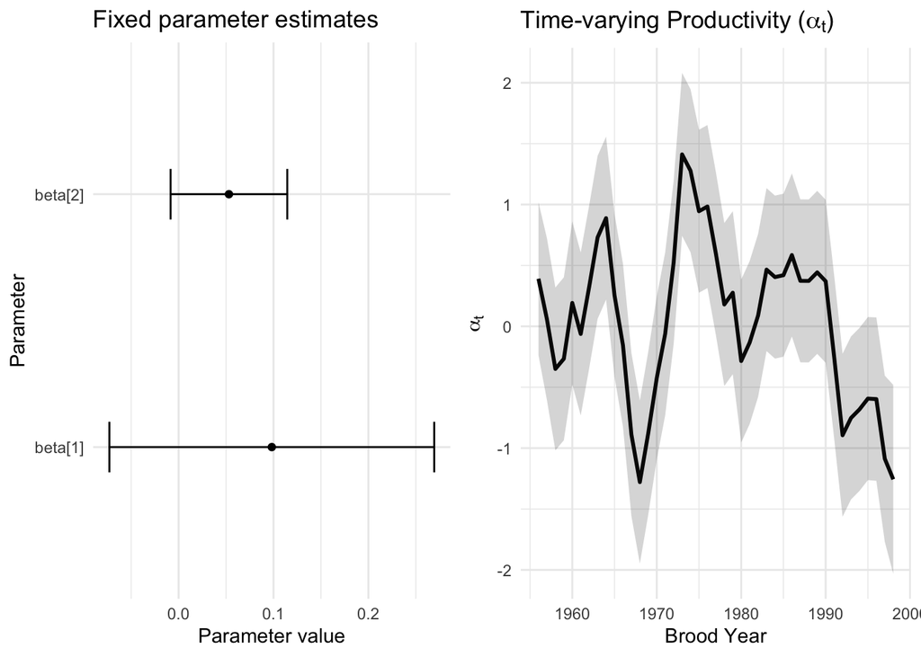

```r
# Extract and plot fixed parameter means and SEs
beta_1_mu = mod4CIs$parMean[1]
beta_1_se = mod4CIs$par.se$A[1,1]
beta_2_mu = mod4CIs$parMean[2]
beta_2_se = mod4CIs$par.se$A[2,1]

# Extract the states
alpha_mu = mod4$states[1, ]
alpha_se = mod4$states.se[1, ]

ggarrange(
data.frame(
  Parameter = c("beta[1]", "beta[2]"),
  Mean = c(beta_1_mu, beta_2_mu),
  SE = c(beta_1_se, beta_2_se)
) %>%

  ggplot(aes(x = Parameter, y = Mean)) +
  geom_point() +
  geom_errorbar(aes(ymin = Mean - SE, ymax = Mean + SE), width = 0.2) +
  ggtitle("Fixed parameter estimates") +
  coord_flip() +
  theme_minimal() +
  ylab("Parameter value")

,
data.frame(
  year  = years,
  alpha = alpha_mu,
  se    = alpha_se
) %>%

  ggplot(aes(x = year, y = alpha)) +
  geom_line(size = 1) +
  geom_ribbon(aes(ymin = alpha - 2 * alpha_se, ymax = alpha + 2 * alpha_se), alpha = 0.2) +
  labs(title = expression(paste("Time-varying Productivity (", alpha[t], ")")),
       x = "Brood Year", y = expression(alpha[t])) +
  theme_minimal()
)
```

## Forecasting the best model (intercept varying only)

5. Based on AICc, which of the models above is the most parsimonious? Is it well behaved (i.e., are the model assumptions met)? Plot the model forecasts for the best model. Is this a good forecast model?

```r
aicc_table <- data.frame(
  Model = c(
    "Model 1: Intercept Only",
    "Model 2: Ricker with Static Slope",
    "Model 3: Summer PDO",
    "Model 4: Winter PDO"
  ),
  Description = c(
    "αₜ only",
    "αₜ + static β",
    "αₜ + δₜ (PDO summer)",
    "αₜ + δₜ (PDO winter)"
  ),
  AICc = c(
    Intcpt_only$AICc,
    SlopeIntcptVarying$AICc,
    mod3$AICc,
    mod4$AICc
  )
)

knitr::kable(aicc_table, digits = 2, caption = "AICc values for models 1 - 4")
```

AICc values for models 1 - 4

[output not shown]

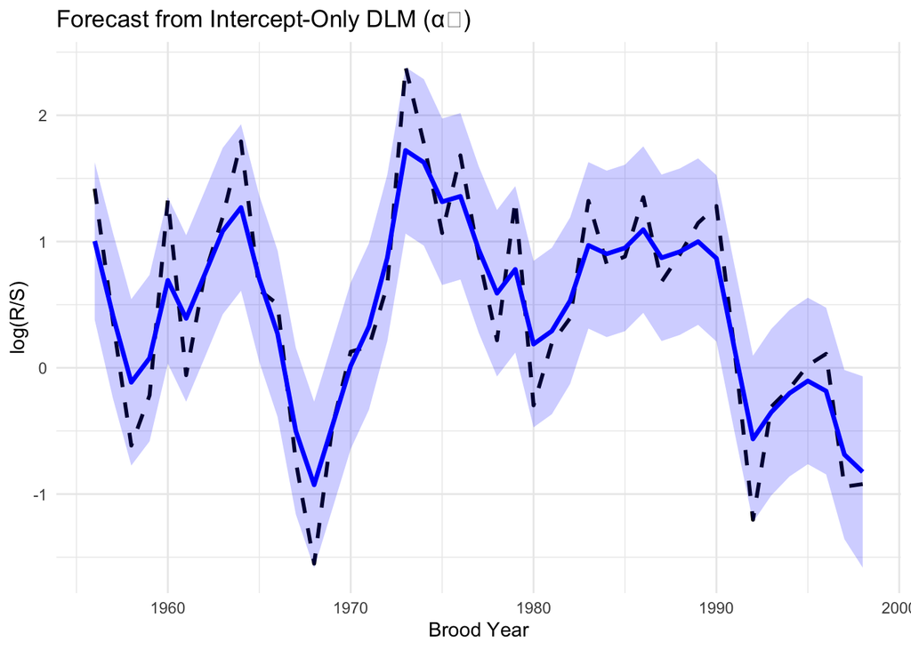

```r
# ---- Forecast from Intercept-Only Model using alpha_t ----
# This model assumes productivity (alpha_t) varies over time, with no density dependence.

Intcpt_only_CIs <- MARSSparamCIs(Intcpt_only)

# Extract time-varying productivity estimates (alpha_t) from the MARSS model output
alpha_t <- Intcpt_only_CIs$states[1, ]

# Extract standard errors for each year's alpha_t estimate
# This will allow us to build 95% confidence intervals
alpha_se <- Intcpt_only_CIs$states.se[1, ]

# Create a data frame that includes:
# - Year
# - Fitted values (alpha_t)
# - Upper/lower confidence intervals
# - Observed log(R/S)
forecast_df_alt <- data.frame(
  year = SR_clean$brood_year,
  fitted = alpha_t,
  upper = alpha_t + 2 * alpha_se,
  lower = alpha_t - 2 * alpha_se,
  observed = SR_clean$log_RS
)

# Load the ggplot2 package for plotting
library(ggplot2)

# Plot:
# - Dashed black line = actual observed productivity (log(R/S))
# - Blue line = modeled alpha_t estimates (fitted)
# - Shaded blue ribbon = 95% confidence band around alpha_t
ggplot(forecast_df_alt, aes(x = year)) +
  geom_line(aes(y = observed), color = "black", linetype = "dashed", linewidth = 1) +
  geom_line(aes(y = fitted), color = "blue", linewidth = 1.2) +
  geom_ribbon(aes(ymin = lower, ymax = upper), fill = "blue", alpha = 0.2) +
  labs(
    title = "Forecast from Intercept-Only DLM (αₜ)",
    y = "log(R/S)",
    x = "Brood Year"
  ) +
  theme_minimal()
```

6. Consider other environmental factors that could influence the time-varying intrinsic productivity of these salmon. For example, are there other large-scale indices of ocean conditions (e.g., sea-surface temperature, El Niño Southern Oscillation)? You could also consider the possible influence of other salmon stocks such as those we examined in Lab 1.

```r
# ------------------------------
# Part 6: Additional Covariate Model – SST Anomaly Example
# ------------------------------

# Step 1: Simulate a synthetic SST anomaly covariate
# This is just a placeholder for a real environmental dataset
# It creates a sine-wave like pattern across years to mimic SST variability
sst_anomaly <- scale(sin(1:ncol(logRS) / 3))  # scaled sine wave
sst_anomaly <- matrix(sst_anomaly, nrow = 1)  # convert to 1-row matrix for MARSS

# Step 2: Create time-varying Z matrix (maps covariates to observations)
# We model 2 latent states: alpha_t (intercept) and delta_t (SST effect)
Z6 <- array(NA, dim = c(1, 2, ncol(logRS)))  # 3D array: obs x states x time
for (t in 1:ncol(logRS)) {
  Z6[1, 1, t] <- 1                 # constant intercept
  Z6[1, 2, t] <- sst_anomaly[1, t] # covariate value at time t
}

# Step 3: Define the MARSS model structure
mod.list.6 <- list(
  B = diag(2),              # states follow random walks (identity matrix)
  U = matrix(0, 2, 1),      # no drift term
  Q = "unconstrained",      # estimate process error for each state
  Z = Z6,                   # time-varying Z matrix with SST covariate
  A = matrix(0),            # no fixed intercept in observation equation
  R = "unconstrained",      # estimate observation error variance
  x0 = "unconstrained"      # estimate initial state (alpha_0 and delta_0)
)

# Step 4: Set initial values for state estimates
init_vals6 <- list(x0 = matrix(c(0, 0), 2, 1))

# Step 5: Fit the model
model6_covariate_fit <- MARSS(logRS, model = mod.list.6, inits = init_vals6, control = list(maxit = 2000))
```

```
## Success! abstol and log-log tests passed at 62 iterations.
## Alert: conv.test.slope.tol is 0.5.
## Test with smaller values (<0.1) to ensure convergence.
##
## MARSS fit is
## Estimation method: kem
## Convergence test: conv.test.slope.tol = 0.5, abstol = 0.001
## Estimation converged in 62 iterations.
## Log-likelihood: -50.77677
## AIC: 113.5535   AICc: 115.8869
##
##         Estimate
## R.R       0.2325
## Q.(1,1)   0.0717
## Q.(2,1)  -0.0572
## Q.(2,2)   0.1498
## x0.X1     1.4955
## x0.X2    -1.3507
## Initial states (x0) defined at t=0
##
## Standard errors have not been calculated.
## Use MARSSparamCIs to compute CIs and bias estimates.
```

##Plotting the estimated states from Model 6:

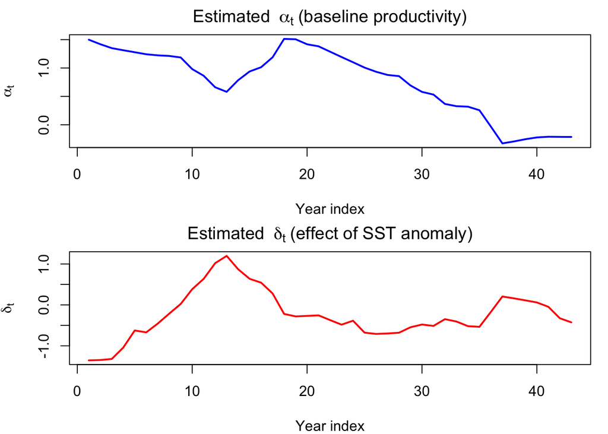

```r
# ------------------------------------------------------------
# Plotting the estimated states from Model 6 (with SST anomaly)
# ------------------------------------------------------------

# Extract alpha_t (baseline productivity) and delta_t (covariate effect) from model output
alpha_t <- model6_covariate_fit$states[1, ]
delta_t <- model6_covariate_fit$states[2, ]

# Set up a 2-row plotting area: one for alpha_t, one for delta_t
par(mfrow = c(2, 1), mar = c(4, 4, 2, 1))  # layout with appropriate margins

# Plot alpha_t over time (baseline productivity)
plot(alpha_t, type = "l", col = "blue", lwd = 2,
     xlab = "Year index",
     ylab = expression(alpha[t]),
     main = expression("Estimated "~alpha[t]~"(baseline productivity)"))

# Plot delta_t over time (covariate effect from SST anomaly)
plot(delta_t, type = "l", col = "red", lwd = 2,
     xlab = "Year index",
     ylab = expression(delta[t]),
     main = expression("Estimated "~delta[t]~"(effect of SST anomaly)"))
```

### Final AICc comparison

```r
# ------------------------------------------------------------
# Final AICc Comparison Table for All Models (Models 1–6)
# ------------------------------------------------------------

# Build a summary table of model names, descriptions, and AICc values
aicc_table <- data.frame(
  Model = c(
    "Model 1: Intercept Only",
    "Model 2: Ricker with Static Slope",
    "Model 3: Summer PDO",
    "Model 4: Winter PDO",
    "Model 6: SST Anomaly"
  ),
  Description = c(
    "αₜ only",
    "αₜ + static β",
    "αₜ + δₜ (PDO summer)",
    "αₜ + δₜ (PDO winter)",
    "αₜ + δₜ (synthetic SST)"
  ),
  AICc = c(
    Intcpt_only$AICc,
    SlopeIntcptVarying$AICc,
    mod3$AICc,
    mod4$AICc,
    model6_covariate_fit$AICc
  )
)

# Use knitr to print a clean markdown table in the knitted HTML report
knitr::kable(aicc_table, digits = 2, caption = "AICc values for all fitted models")
```

AICc values for all fitted models

[output not shown]

# Methods

## Model Structure

General format of a Dynamic Linear Model (DLM) using a state-space structure: This is how all models in this lab are structured, using MARSS.

### Observation equation (what we actually measure):

$y_t = Z_t * x_t + A + v_t$  
- $y_t$ is the observed value at time $t$ (log(recruits/spawners))  
- $x_t$ is the hidden state (like productivity alpha_t)  
- $Z_t$ tells how the state affects the observation (can include covariates)  
- $A$ is a fixed offset (set to 0 in our models)  
- $v_t$ is observation error, assumed to follow a normal distribution: $v_t ~ N(0, R)$

### State equation (how the hidden states evolve over time):

$x_t = B * x_{t-1} + U + w_t$  
- $x_t$ is the hidden state at time $t$  
- $B$ defines how the state changes over time (identity matrix for random walks)  
- $U$ is a fixed drift (set to 0 here)  
- $w_t$ is process error (random noise in the state), $ w_t ~ N(0, Q) $

### Each model below is a special case of this general framework:

#### Model 1: Intercept-Only DLM (no covariates or slope)

This is the simplest model:  
- $\alpha_t$ varies year to year (captures productivity)  
- No covariates included

Observation: $y_t = α_t + v_t$  
State transition: $α_t = α_{t-1} + w_t$

This model assumes productivity is time-varying, but there’s no effect of density or environmental conditions — it’s just $alpha_t$ driving changes in recruitment.

#### Model 2: Intercept + Static Slope (Ricker with density dependence)

This model includes a fixed effect of log(spawners)  
- Alpha_t still varies over time  
- Beta (slope) is constant

Observation: $y_t = α_t + β * log(spawners_t) + v_t$  
State transition: $α_t = α_{t-1} + w_t$

Beta doesn’t change across years — it represents a constant density-dependent effect.

#### Models 3–6: Intercept + Covariate Effect (PDO or SST)

# Team contributions

All team members helped decide on the overall goal and structure of the analyses, BM ran analyses for questions 1 - 2, MB ran analyses for questions 3 - 4, and MO ran analyses for question 5. All team members contributed to the final write-up and discussion of results.